# TUGAS PROJECT CLUSTERING

# 1. PREPARATION DATA OBESITY

```r
# 1. Membaca Data Diabetes
raw_data <- read.csv2("D:/KULIAH/SEMESTER 4/MATKUL/STAT MACHINE LEARNING/DATA OBESITAS.csv")

# 2. Mengambil 200 baris pertama dan mengubah nama kolom menjadi x1 sampai x4
data_sml <- data.frame(
  x1 = as.numeric(raw_data[1:200, "Age"]),
  x2 = as.numeric(raw_data[1:200, "Height"]),
  x3 = as.numeric(raw_data[1:200, "Weight"]),
  x4 = as.numeric(raw_data[1:200, "CH2O"])
)

# 3. MENAMPILKAN TABEL DATA INTERAKTIF DI RPUBS
library(DT)
datatable(data_sml, caption = "Tabel 1: 200 Baris Pertama Data Obesitas dari
          Repositori UCI")
```

|  | x1 | x2 | x3 | x4 |
| --- | --- | --- | --- | --- |
| 1 | 21 | 1.62 | 64 | 2 |
| 2 | 21 | 1.52 | 56 | 3 |
| 3 | 23 | 1.8 | 77 | 2 |
| 4 | 27 | 1.8 | 87 | 2 |
| 5 | 22 | 1.78 | 89.8 | 2 |
| 6 | 29 | 1.62 | 53 | 2 |
| 7 | 23 | 1.5 | 55 | 2 |
| 8 | 22 | 1.64 | 53 | 2 |
| 9 | 24 | 1.78 | 64 | 2 |
| 10 | 22 | 1.72 | 68 | 2 |

[output cut: 190 more lines]

Studi kasus ini menggunakan data yang diambil dari UCI Machine Learning Repository, yaitu dataset “Estimation of Obesity Levels Based on Eating Habits and Physical Condition”. Dataset ini berasal dari penelitian yang dilakukan oleh Polechor dan de la Hoz (2019) di Meksiko, Peru, dan Kolombia. Link sumber data sebagai berikut :https://archive.ics.uci.edu/dataset/544/estimation+of+obesity+levels+based+on+eating+habits+and+physical+condition

Pada studi kasus ini digunakan 200 baris pertama dengan fokus pada 4 variabel numerik, yaitu Age, Height, Weight, dan CH20. Pemilihan dataset ini dikarenakan variabel fisik medis seperti Age(usia), Height(tinggi badan), Weight(berat badan), dan CH20 memiliki skala satuan yang berbeda jauh. Hal ini ideal untuk digunakan dalam berbagai algoritma clustering berbasis jarak.

```r
# Menjalankan PCA dengan kondisi DENGAN SCALING (scale. = TRUE)
pca <- prcomp(data_sml, scale. = TRUE)
summary(pca)
```

```
## Importance of components:
##                           PC1    PC2    PC3     PC4
## Standard deviation     1.3212 0.9999 0.9631 0.57198
## Proportion of Variance 0.4364 0.2499 0.2319 0.08179
## Cumulative Proportion  0.4364 0.6863 0.9182 1.00000
```

```r
# Mengambil koordinat PC1 dan PC2 untuk keperluan plot grafik
data_pca <- as.data.frame(pca$x[, 1:2])
data_pca$Label <- paste0("P", 1:200)
```

Langka pertama yang dilakukan yaitu standarisasi (Scaling) dan reduksi dimensi (PCA) agar hasil pengelompokkan menjadi objektif dan visualisasinya dapat dipetakan dalam ruang 2 dimensi.

# 2. PROSES CLUSTERING (K-MEANS & PAM)

```r
library(cluster)
```

```r
library(ggplot2)
library(kmed)
k_kluster <- 3
```

## A. Metode K-Means

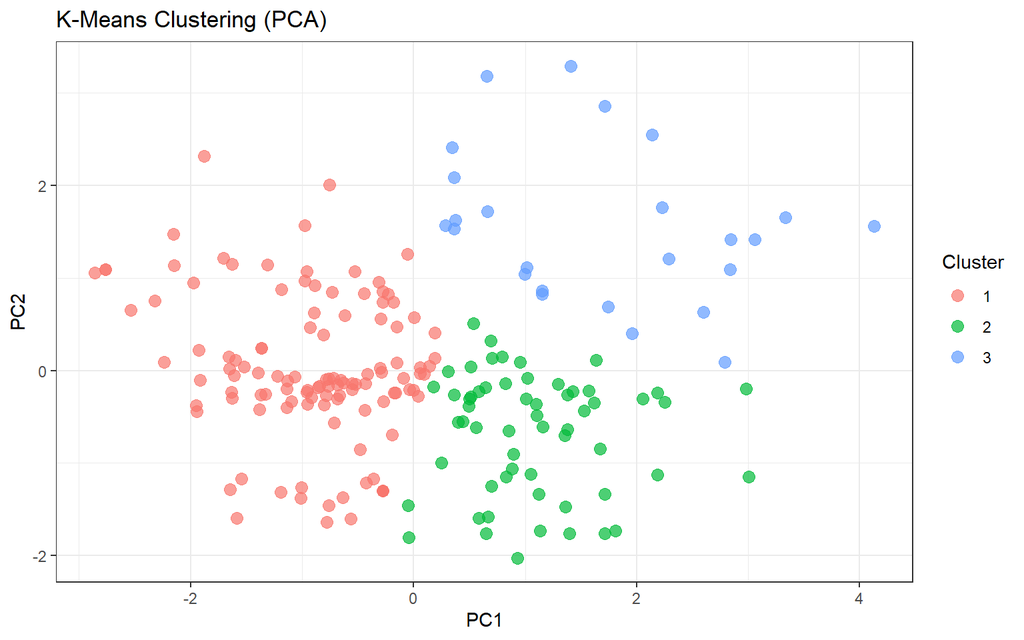

```r
# A. METODE K-MEANS
#--------------------------------
set.seed(123) # Agar hasil pengacakan K-Means konsisten
km_res <- kmeans(data_pca[, 1:2], centers = k_kluster)
data_pca$Cluster_KM <- as.factor(km_res$cluster)

# Visualisasi Plot K-Means
ggplot(data_pca, aes(x = PC1, y = PC2, col = Cluster_KM)) +
  geom_point(size = 3, alpha = 0.7) +
  theme_bw() +
  labs(title = "K-Means Clustering (PCA)", col = "Cluster")
```

```r
# Tabel Kontingensi Jumlah Anggota K-Means
table(Cluster_KMeans = data_pca$Cluster_KM)
```

```
## Cluster_KMeans
##   1   2   3
## 116  59  25
```

K-Means digunakan untuk membagi data secara tegas (hard clustering) ke dalam sejumlah k kelompok dengan meminimalkan varians jarak antar setiap objek data dengan pusat kluster terdekat. Berdasarkan output yang didapat, K-Means dengan parameter k=3 berhasil membagi data ke dalam tiga kelompok, yaitu Cluster 1 sebanyak 116 pasien, Cluster 2 sebanyak 59 pasien, dan Cluster 3 sebanyak 25 pasien. Pada plot pembagian kluster ini ditandai dengan perbedaan warna tiap Cluster.  
Perbedaan jumlah anggota yang didapatkan tiap Cluster menunjukkan karakteristik fisik dari sampel pasien tidak tersebar merata sehingga memiliki kecenderungan terpusat pada kondisi fisik tertentu dan jumlahnya semakin menurun ketika kondisi medis yang ekstrem.

## B. Metode PAM

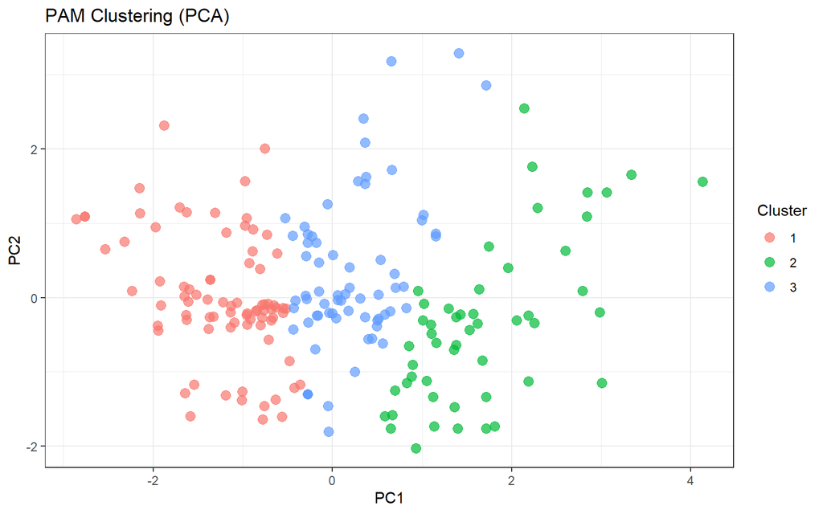

```r
# B. METODE PAM (K-MEDOIDS)
#-----------------------------------
set.seed(123)
pam_res <- pam(data_pca[, 1:2], k = k_kluster)
data_pca$Cluster_PAM <- as.factor(pam_res$clustering)

# Visualisasi Plot PAM
ggplot(data_pca, aes(x = PC1, y = PC2, col = Cluster_PAM)) +
  geom_point(size = 3, alpha = 0.7) +
  theme_bw() +
  labs(title = "PAM Clustering (PCA)", col = "Cluster")
```

```r
# Tabel Kontingensi Jumlah Anggota PAM
table(Cluster_PAM = data_pca$Cluster_PAM)
```

```
## Cluster_PAM
##  1  2  3
## 81 51 68
```

Partitioning Around Medoids (PAM) merupakan metode klustering berbasis medoid, PAM bekerja secara robust terhadap data pencilan dengan cara memilih objek riil dari dataset pasien sebagai pusat kluster (medoid).  
Berdasarkan output yang didapatkan, PAM membagi data ke dalam tiga kelompok yang lebih merata dibandingkan dengan metode K-Means, yaitu Cluster 1 sebanyak 81 pasien, Cluster 2 sebanyak 51 pasien, dan Cluster 3 sebanyak 68 pasien. Pada plot pembagian kluster ini ditandai dengan perbedaan warna pada tiap kluster, plot PAM membagi area ruang koordinat secara vertikal mengikuti sumbu PC1.Secara visual, Cluster 1 menempati area paling kiri dalam koordinat PC1 negatif, kemudian Cluster 3 berada pada area transisi di bagian tengah, dan Cluster 2 berada pada area paling kanan dalam koordinat PC1 positif. Batas pemisahan secara vertikal ini menunjukkan bahwa pendekatan objek medoid dapat memberikan alternatif pengelompokan kondisi pasien yang terstruktur.

# 3. TABEL KONTINGENSI & VALIDASI

```r
# 3. TABEL KONTINGENSI & VALIDASI
# ====================================================================

# A. Cetak Tabel Kontingensi Perbandingan Anggota
cat("\n--- Tabel Kontingensi: K-Means vs PAM ---\n")
```

```
##
## --- Tabel Kontingensi: K-Means vs PAM ---
```

```r
print(table(K_Means = data_pca$Cluster_KM, PAM = data_pca$Cluster_PAM))
```

```
##        PAM
## K_Means  1  2  3
##       1 81  0 35
##       2  0 39 20
##       3  0 12 13
```

Berdasarkan output tabel kontingensi yang didapat, yaitu pada Cluster 1 terdapat 81 pasien yang sama-sama dimasukkan ke dalam cluster 1 oleh K-Means dan PAM. Hal ini menunjukkan bahwa terdapat 81 pasien memiliki karakteristik klinis yang kuat dan konsisten, kemudian pada Cluster 2 terdapat 39 pasien yang sama-sama masuk ke dalam Cluster 2 oleh kedua metode tersebut. Tetapi terdapat 12 pasien dalam metode PAM yang masuk ke Cluster 2, namun pada K-Means masuk ke dalam Cluster 3, dan pada Cluster 3 hanya 13 pasien yang sejak awal sudah disepakati oleh K-Means dan PAM untuk masuk ke dalam Cluster 3. Kedua metode tersebut memiliki kecocokan yang searah pada pola diagonal utamanya yaitu 81, 39, dan 13. Pergeseran lain terjadi karena K-Means mudah bergeser (bias) akibat keberadaan outlier. Sedangkan metode PAM mempunyai stabilitas yang tinggi karena penentuan pusatnya berdasarkan pada objek pasie riil (medoid), sehingga tidak mudah dipengaruhi oleh data pencilan.

```r
# B. Hitung Matriks Jarak Euclidean
dist_diabetes <- dist(data_sml)

# C. Ekstrak Keanggotaan Cluster dan ID Medoid dari hasil PAM
clustmemb_pam <- pam_res$clustering
clustmed_pam  <- pam_res$id.med

# D. Validasi Silhouette PAM menggunakan Library kmed
library(kmed)
silhouette_pam <- sil(dist_diabetes, clustmed_pam, clustmemb_pam)
# E. Validasi Silhouette K-Means untuk pembanding menggunakan fungsi dasar R
sil_km <- silhouette(km_res$cluster, dist_diabetes)

# F. Menghitung Rata-rata Skor Akhir
avg_km <- mean(sil_km[, 3])
avg_pam <- mean(silhouette_pam$result[, 1])

# Cetak Hasil Skor Akhir
cat("\n--- HASIL VALIDASI SILHOUETTE WIDTH ---\n")
```

```
##
## --- HASIL VALIDASI SILHOUETTE WIDTH ---
```

```r
cat("Rata-rata Silhouette K-Means : ", avg_km, "\n")
```

```
## Rata-rata Silhouette K-Means :  0.3003101
```

```r
cat("Rata-rata Silhouette PAM     : ", avg_pam, "\n\n")
```

```
## Rata-rata Silhouette PAM     :  0.2951814
```

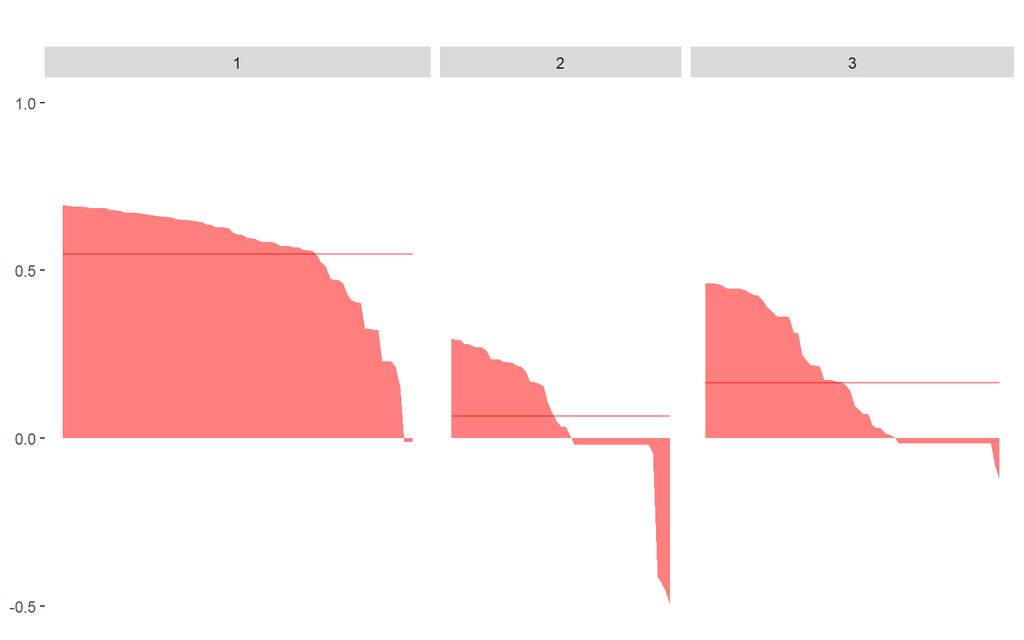

```r
# G.Gambar Grafik Silhouette Plot
silhouette_pam$plot
```

Bedasarkan output validasi Silhouette didapatkan rata-rata silhouette K-Means adalah 0,3003101 dan rata-rata silhouette PAM adalah 0,2951814. Hal ini menunjukkan bahwa K-Means mempunyai tingkat kerapatan (compactness) yang sedikit lebih baik. Kemudian berdasarkan grafik Silhoutte yang didapat terlihat bahwa pada Cluster 1 menunjukkan performa yang terbaik karena terdapat banyak nilai silhouette bernilai positif tinggi. Sedangkan pada Cluster 2 dan Cluster 3 terdapat nilai silhouette yang negative (mengarah ke bawah nilai 0), hal ini mengindikasikan adanya beberapa objek pasien yang salam masuk Cluster atau terdapat objek yang berada di area perbatasan yang tidak jelas. Hal ini wajar terjadi pada data klinis obesitas, karena variasi tubuh pasien sering kali bersinggungan satu sama lain dan tidak selalu terpisah secara mutlak. Dalam data obesitas ini, metode PAM lebih direkomendasikan. Karena metode K-Means lebih sensitif terhadap data pencilan (outlier), yang berdampak pada pembagian jumlah anggota Cluster yang timpang. Sedangkan metode PAM menghasilkan struktur kelompok yang jauh lebih stabil, seimbang, dan realistis secara medis karena pusat kelompoknya memakai data pasien riil (medoid).